# Fitness exercise quality prediction using public dataset

### Practical Machine Learning Project

#### 27.09.2015.

## Introduction

In this project we will predict the quality of fitness exercises using machine learning model built using publicly available data set [1]. The data contain accelerator measurements of a set of professionaly executed exercises in 5 quality levels. The model will learn to distinguish between various quality levels and will be able to predict whether the exercise is done in a good or a bad way.

Some initializing steps first:

```r
rm(list=ls())
memory.limit()
```

```
## [1] 3583
```

```r
library(caret)
library(randomForest)
set.seed(2508978)
```

## Data

Importing the data into *data* and *predictingData* variables.

```r
data = read.csv("http://d396qusza40orc.cloudfront.net/predmachlearn/pml-training.csv")
dim(data)
```

```
## [1] 19622   160
```

```r
predictingData = read.csv("http://d396qusza40orc.cloudfront.net/predmachlearn/pml-testing.csv")
dim(predictingData)
```

```
## [1]  20 160
```

To have a glimpse of what are we dealing with, let’s print values of all features for 4 different exercises.

```r
options(width=120)
t(data[1:4, ])
```

```
##                          1                  2                  3                  4
## X                        "1"                "2"                "3"                "4"
## user_name                "carlitos"         "carlitos"         "carlitos"         "carlitos"
## raw_timestamp_part_1     "1323084231"       "1323084231"       "1323084231"       "1323084232"
## raw_timestamp_part_2     "788290"           "808298"           "820366"           "120339"
## cvtd_timestamp           "05/12/2011 11:23" "05/12/2011 11:23" "05/12/2011 11:23" "05/12/2011 11:23"
## new_window               "no"               "no"               "no"               "no"
## num_window               "11"               "11"               "11"               "12"
## roll_belt                "1.41"             "1.41"             "1.42"             "1.48"
## pitch_belt               "8.07"             "8.07"             "8.07"             "8.05"
## yaw_belt                 "-94.4"            "-94.4"            "-94.4"            "-94.4"
## total_accel_belt         "3"                "3"                "3"                "3"
## kurtosis_roll_belt       ""                 ""                 ""                 ""
## kurtosis_picth_belt      ""                 ""                 ""                 ""
## kurtosis_yaw_belt        ""                 ""                 ""                 ""
## skewness_roll_belt       ""                 ""                 ""                 ""
## skewness_roll_belt.1     ""                 ""                 ""                 ""
## skewness_yaw_belt        ""                 ""                 ""                 ""
## max_roll_belt            NA                 NA                 NA                 NA
## max_picth_belt           NA                 NA                 NA                 NA
## max_yaw_belt             ""                 ""                 ""                 ""
## min_roll_belt            NA                 NA                 NA                 NA
## min_pitch_belt           NA                 NA                 NA                 NA
## min_yaw_belt             ""                 ""                 ""                 ""
## amplitude_roll_belt      NA                 NA                 NA                 NA
## amplitude_pitch_belt     NA                 NA                 NA                 NA
## amplitude_yaw_belt       ""                 ""                 ""                 ""
## var_total_accel_belt     NA                 NA                 NA                 NA
## avg_roll_belt            NA                 NA                 NA                 NA
## stddev_roll_belt         NA                 NA                 NA                 NA
## var_roll_belt            NA                 NA                 NA                 NA
## avg_pitch_belt           NA                 NA                 NA                 NA
## stddev_pitch_belt        NA                 NA                 NA                 NA
## var_pitch_belt           NA                 NA                 NA                 NA
## avg_yaw_belt             NA                 NA                 NA                 NA
## stddev_yaw_belt          NA                 NA                 NA                 NA
## var_yaw_belt             NA                 NA                 NA                 NA
## gyros_belt_x             "0.00"             "0.02"             "0.00"             "0.02"
## gyros_belt_y             "0"                "0"                "0"                "0"
## gyros_belt_z             "-0.02"            "-0.02"            "-0.02"            "-0.03"
```

[output cut: 106 more lines]

```
## stddev_pitch_forearm     NA                 NA                 NA                 NA
## var_pitch_forearm        NA                 NA                 NA                 NA
## avg_yaw_forearm          NA                 NA                 NA                 NA
## stddev_yaw_forearm       NA                 NA                 NA                 NA
## var_yaw_forearm          NA                 NA                 NA                 NA
## gyros_forearm_x          "0.03"             "0.02"             "0.03"             "0.02"
## gyros_forearm_y          " 0.00"            " 0.00"            "-0.02"            "-0.02"
## gyros_forearm_z          "-0.02"            "-0.02"            " 0.00"            " 0.00"
## accel_forearm_x          "192"              "192"              "196"              "189"
## accel_forearm_y          "203"              "203"              "204"              "206"
## accel_forearm_z          "-215"             "-216"             "-213"             "-214"
## magnet_forearm_x         "-17"              "-18"              "-18"              "-16"
## magnet_forearm_y         "654"              "661"              "658"              "658"
## magnet_forearm_z         "476"              "473"              "469"              "469"
## classe                   "A"                "A"                "A"                "A"
```

Some features does not contain any prediction value. We can manually select others containing meaningful numerical content, but avoiding timestamps and other inputs not related to accelerator measurements.

```r
cols = c('roll_belt', 'pitch_belt', 'yaw_belt', 'total_accel_belt', 'gyros_belt_x', 'gyros_belt_y',
         'gyros_belt_z', 'accel_belt_x', 'accel_belt_y', 'accel_belt_z', 'magnet_belt_x', 'magnet_belt_y',
         'magnet_belt_z', 'roll_arm', 'pitch_arm', 'yaw_arm', 'total_accel_arm', 'gyros_arm_x', 'gyros_arm_y',
         'gyros_arm_z', 'accel_arm_x', 'accel_arm_y', 'accel_arm_z', 'magnet_arm_x', 'magnet_arm_y',
         'magnet_arm_z', 'roll_dumbbell', 'pitch_dumbbell', 'yaw_dumbbell', 'total_accel_dumbbell',
         'gyros_dumbbell_x', 'gyros_dumbbell_y', 'gyros_dumbbell_z', 'accel_dumbbell_x', 'accel_dumbbell_y',
         'accel_dumbbell_z', 'magnet_dumbbell_x', 'magnet_dumbbell_y', 'magnet_dumbbell_z', 'roll_forearm',
         'pitch_forearm', 'yaw_forearm', 'total_accel_forearm', 'gyros_forearm_x', 'gyros_forearm_y',
         'gyros_forearm_z', 'accel_forearm_x', 'accel_forearm_y', 'accel_forearm_z', 'magnet_forearm_x',
         'magnet_forearm_y', 'magnet_forearm_z')
```

Check if some of the reduced data contain invalid inputs, hope not…

```r
usingData = data[, c(cols,'classe')]
cat("NA in usingData:", any(is.na(usingData) == TRUE))
```

```
## NA in usingData: FALSE
```

```r
predicting = predictingData[, cols]
cat("NA in predicting:", any(is.na(predicting) == TRUE))
```

```
## NA in predicting: FALSE
```

Looks everything is OK.

During the detailed data analysis I noticed some channels contain weird values. You can see the outliers in the following plots.

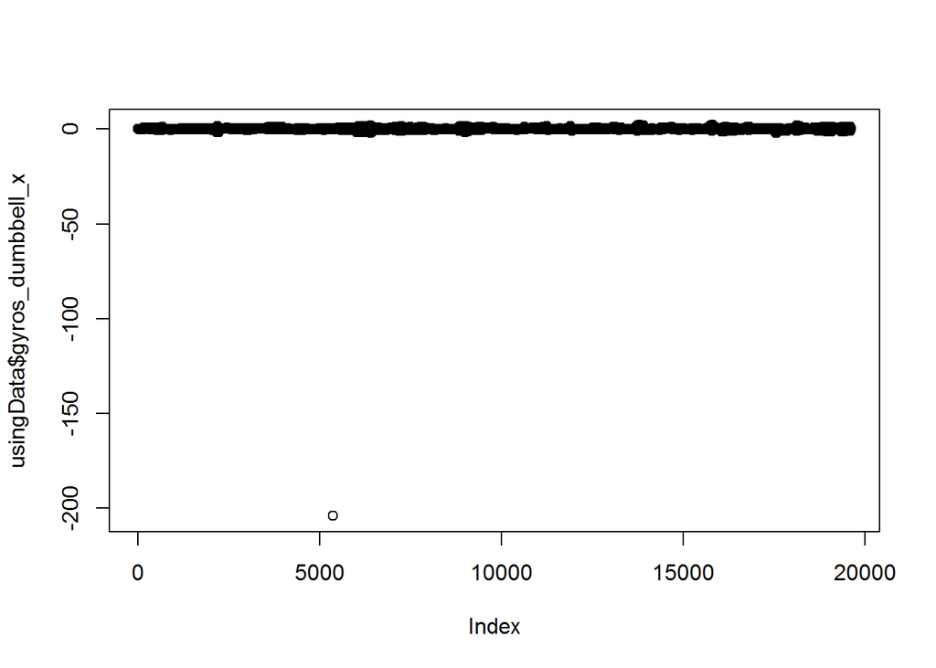

```r
plot(usingData$gyros_dumbbell_x)
```

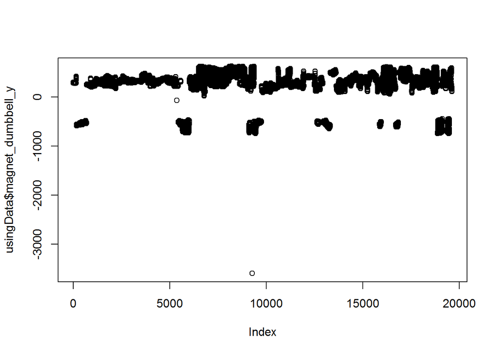

```r
plot(usingData$magnet_dumbbell_y)
```

I believe these are the result of some kind of measurement errors, so I removed them from the data.

```r
outlier1 = which(usingData$gyros_dumbbell_x < -200)
outlier2 = which(usingData$magnet_dumbbell_y < -3000)
usingData = usingData[-c(outlier1, outlier2), ]
```

## Training

Now we split the data into training and testing sets. Roughly 60% of the data is used for the training set, and the rest for the testing set.

```r
trainingCases = createDataPartition(usingData$classe, p = 0.6, list = FALSE)

training = usingData[trainingCases, ]
dim(training)
```

```
## [1] 11775    53
```

```r
testing = usingData[-trainingCases, ]
dim(testing)
```

```
## [1] 7845   53
```

Ever since I read this great article on benchmarking many currently available classifiers (“Do We Need Hundreds of Classifiers to Solve Real World Classification Problems?”) [2], I always try with some Random Forests classifier first. I highly recommend it to everyone even remotely interested in Machine Learning.

I tried using caret’s rf (had some fancy features on my mind), but it was too slow. I ended up with ‘internal’ randomForest, with sweet spot at ntree=1000. Training process takes about 2 minutes.

```r
ntree=1000

time0 = Sys.time()
rfModel = randomForest(classe ~ ., data = training, ntree = ntree, importance = TRUE)
Sys.time() - time0
```

```
## Time difference of 2.051584 mins
```

## Testing / validating

Once we have the model, let’s have a looks what we got. One of many good things about Random Forests classifiers is that model accuracy can be ‘self-estimated’ [3]. In our case out-of-the-box (OOB) error is *0.7%*. That’s more than nice, we can work with that!

```r
rfModel
```

```
##
## Call:
##  randomForest(formula = classe ~ ., data = training, ntree = ntree,      importance = TRUE)
##                Type of random forest: classification
##                      Number of trees: 1000
## No. of variables tried at each split: 7
##
##         OOB estimate of  error rate: 0.66%
## Confusion matrix:
##      A    B    C    D    E  class.error
## A 3345    3    0    0    0 0.0008960573
## B   10 2264    4    0    0 0.0061457419
## C    0   16 2034    4    0 0.0097370983
## D    0    0   30 1898    2 0.0165803109
## E    0    0    3    6 2156 0.0041570439
```

More OOB info is available by applying *predict* to the model without specifing new data. This way we get accuracy of *99.3%*, some info on sensitivity, specificity…

```r
oob = predict(rfModel)
confusionMatrix(oob, training$classe)
```

```
## Confusion Matrix and Statistics
##
##           Reference
## Prediction    A    B    C    D    E
##          A 3345   10    0    0    0
##          B    3 2264   16    0    0
##          C    0    4 2034   30    3
##          D    0    0    4 1898    6
##          E    0    0    0    2 2156
##
## Overall Statistics
##
##                Accuracy : 0.9934
##                  95% CI : (0.9917, 0.9948)
##     No Information Rate : 0.2843
##     P-Value [Acc > NIR] : < 2.2e-16
##
##                   Kappa : 0.9916
##  Mcnemar's Test P-Value : NA
##
## Statistics by Class:
##
##                      Class: A Class: B Class: C Class: D Class: E
## Sensitivity            0.9991   0.9939   0.9903   0.9834   0.9958
## Specificity            0.9988   0.9980   0.9962   0.9990   0.9998
## Pos Pred Value         0.9970   0.9917   0.9821   0.9948   0.9991
## Neg Pred Value         0.9996   0.9985   0.9979   0.9968   0.9991
## Prevalence             0.2843   0.1935   0.1744   0.1639   0.1839
## Detection Rate         0.2841   0.1923   0.1727   0.1612   0.1831
## Detection Prevalence   0.2849   0.1939   0.1759   0.1620   0.1833
## Balanced Accuracy      0.9990   0.9959   0.9932   0.9912   0.9978
```

Applying the model to the testing set we get the confirmation of the accuracy (99.3%). Rest of the statistics is rather similar to OOB estimation, so once more Random Forests OOB is proven to be a rather good and unbiased methodology. Because of this, some say one doesn’t have to use testing set at all for Random Forests models, and rely on OOB estimations alone, but I take that with a grain of salt.

```r
testingResult = predict(rfModel, newdata=testing[, names(testing) != "classe"])
confusionMatrix(testingResult, testing$classe)
```

```
## Confusion Matrix and Statistics
##
##           Reference
## Prediction    A    B    C    D    E
##          A 2224   14    0    0    0
##          B    3 1500   10    0    0
##          C    0    4 1356   15    0
##          D    1    0    2 1270    4
##          E    3    0    0    1 1438
##
## Overall Statistics
##
##                Accuracy : 0.9927
##                  95% CI : (0.9906, 0.9945)
##     No Information Rate : 0.2844
##     P-Value [Acc > NIR] : < 2.2e-16
##
##                   Kappa : 0.9908
##  Mcnemar's Test P-Value : NA
##
## Statistics by Class:
##
##                      Class: A Class: B Class: C Class: D Class: E
## Sensitivity            0.9969   0.9881   0.9912   0.9876   0.9972
## Specificity            0.9975   0.9979   0.9971   0.9989   0.9994
## Pos Pred Value         0.9937   0.9914   0.9862   0.9945   0.9972
## Neg Pred Value         0.9988   0.9972   0.9981   0.9976   0.9994
## Prevalence             0.2844   0.1935   0.1744   0.1639   0.1838
## Detection Rate         0.2835   0.1912   0.1728   0.1619   0.1833
## Detection Prevalence   0.2853   0.1929   0.1753   0.1628   0.1838
## Balanced Accuracy      0.9972   0.9930   0.9941   0.9932   0.9983
```

## Predicting

Now we can use the model to predict the quality of the exercises in predicting data set. At this point we will use another Random Forests trick by setting *predict.all* variable to *TRUE*. This way the model will preserve prediction information for all trees in the model. We will use it later, as you’ll see in a few moments.

```r
result = predict(rfModel, newdata=predicting, predict.all = TRUE)
result$aggregate
```

```
##  1  2  3  4  5  6  7  8  9 10 11 12 13 14 15 16 17 18 19 20
##  B  A  B  A  A  E  D  B  A  A  B  C  B  A  E  E  A  B  B  B
## Levels: A B C D E
```

So this is my aggregate prediction result. Project submission checker gives it 100% approval rating.

Now we’ll make some use of the prediction data of every single tree in Random Forests model mentioned before. First we define function that counts the votes trees made for some prediction case (exercise). This will tell use whether it was a clear decision, i.e. how many trees voted for some of the options (quality classes). This number is normalized with the number of trees in the model (*ntree*), this way we get the percentages of votes for any of the classes. This is also one of Random Forests features I really like, you can always get it without much additional effort and you get some sense of your result.

```r
ratio = function(r, classe) {
  return( length(which(r == classe)) / ntree )
}

abcde = function(r) {
  ra = ratio(r, "A")
  rb = ratio(r, "B")
  rc = ratio(r, "C")
  rd = ratio(r, "D")
  re = ratio(r, "E")

  return( c(ra, rb, rc, rd, re) )
}

probs = data.frame(c(), c(), c(), c(), c())

for (i in 1:20) {
  probs = rbind(probs, abcde(result$individual[i,]))
}
```

Finally, this is the statistics. If the model is good, the decisions should be clear, done with high percentage of votes for some single class, which really is the case as you can see below.

```r
colnames(probs) = c("A", "B", "C", "D", "E")
probs
```

```
##        A     B     C     D     E
## 1  0.048 0.833 0.089 0.019 0.011
## 2  0.921 0.038 0.026 0.004 0.011
## 3  0.148 0.660 0.129 0.008 0.055
## 4  0.904 0.015 0.056 0.024 0.001
## 5  0.957 0.014 0.022 0.001 0.006
## 6  0.010 0.081 0.080 0.025 0.804
## 7  0.021 0.008 0.061 0.886 0.024
## 8  0.092 0.629 0.097 0.139 0.043
## 9  1.000 0.000 0.000 0.000 0.000
## 10 0.986 0.011 0.000 0.002 0.001
## 11 0.054 0.755 0.090 0.062 0.039
## 12 0.030 0.058 0.825 0.024 0.063
## 13 0.008 0.970 0.003 0.008 0.011
## 14 1.000 0.000 0.000 0.000 0.000
## 15 0.007 0.046 0.043 0.035 0.869
## 16 0.019 0.041 0.003 0.026 0.911
## 17 0.995 0.002 0.000 0.000 0.003
## 18 0.062 0.845 0.009 0.063 0.021
## 19 0.092 0.872 0.006 0.021 0.009
## 20 0.001 0.997 0.001 0.001 0.000
```

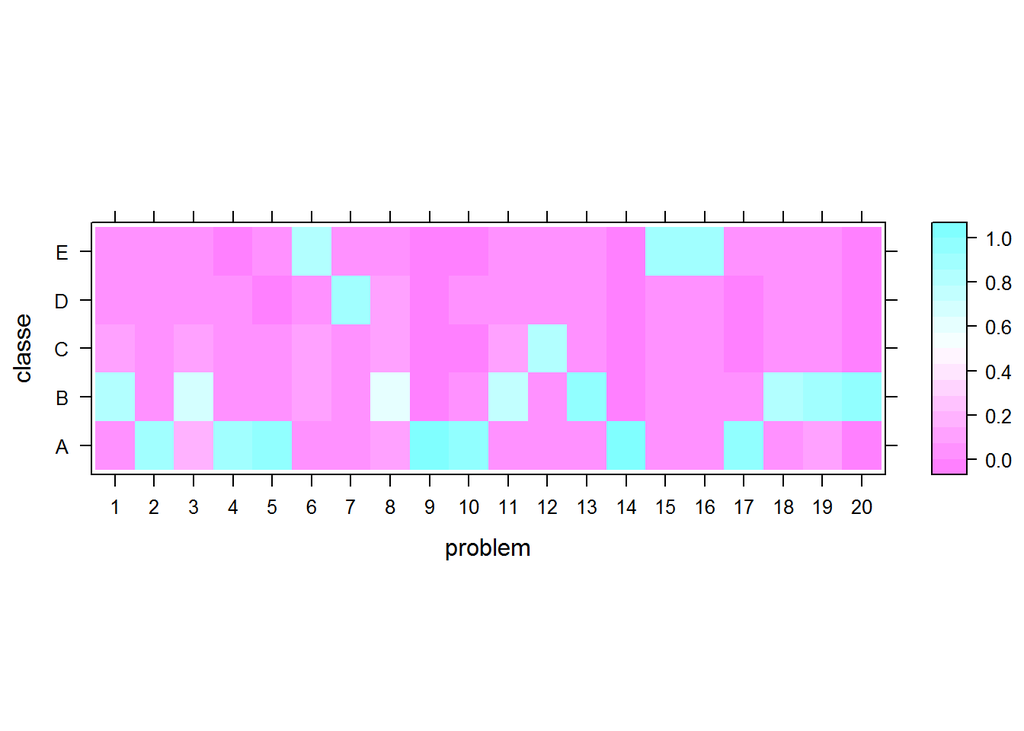

```r
levelplot(data.matrix(probs), xlab="problem", ylab="classe")
```

The end! Make sure you have a look at [2]…

## References

[1] Ugulino, W.; Cardador, D.; Vega, K.; Velloso, E.; Milidiu, R.; Fuks, H. Wearable Computing: Accelerometers’ Data Classification of Body Postures and Movements. Proceedings of 21st Brazilian Symposium on Artificial Intelligence. Advances in Artificial Intelligence - SBIA 2012. In: Lecture Notes in Computer Science. , pp. 52-61. Curitiba, PR: Springer Berlin / Heidelberg, 2012. ISBN 978-3-642-34458-9. DOI: 10.1007/978-3-642-34459-6_6.

[2] Fernández-Delgado, Manuel, et al. “Do we need hundreds of classifiers to solve real world classification problems?.” The Journal of Machine Learning Research 15.1 (2014): 3133-3181.

[3] https://www.stat.berkeley.edu/~breiman/RandomForests/cc_home.htm#ooberr